# **Final Assignment - Bath Soap Segmentation**

Ryan Harris

*December 2020*

## **Prepare Data for Analysis**

#### **Load Dependencies**

```python
%matplotlib inline

import pandas as pd
import numpy as np
import matplotlib.pyplot as plt
import seaborn as sns

from sklearn import preprocessing
from sklearn.cluster import KMeans
from sklearn.preprocessing import StandardScaler
from sklearn.decomposition import PCA
```

#### **Import and Transform Data**

*After importing and trimming missing values, I will strip the % sign from the propositionwise columns and turned the percenatges into the equivalent decimals.*

```python
#Import
soap_df = pd.read_csv('//HARRISSERVER/share/School/Datasets/BathSoap.csv')

#Remove rows with missing values
soap_df = soap_df.dropna()

#Convert %s to decimals
soap_df.iloc[:,19:] = soap_df.iloc[:,19:].apply(lambda x: x.str.strip('%')).astype(float)/100
```

#### **Create Derived Variables**

*In assessing both "purchase behavior" and "basis for purchase", there are categories in each which are too broad to use for analysis (Br.Cd. & PropCat 5-15). Because K Means does not work with categorical variables, I will generate a derived variable (as per the recommendation in the assignment) for Br.Cd, and PropCat 5-15. This simply specifies that the customer has a high affinity toward one of the specific categories or brands.*

```python
#Find the max value of Br.Cd. 54,144 : Br.Cd. 5 and assign to new column 'Top Brand %'
soap_df['Top Brand %'] = soap_df.iloc[:,22:30].max(axis=1)

#Find the max value of PropCat5:PropCat15 and assign to new column 'Top PropCat %'
soap_df['Top PropCat %'] = soap_df.iloc[:,35:46].max(axis=1)
```

#### **Normalization**

*Normalize all columns because they will be used for analysis later*

```python
#Make a copy of df for normalization
soap_df_norm = soap_df.copy()

#Normalize all columns
scaler = preprocessing.StandardScaler()
soap_df_norm = scaler.fit_transform(soap_df)
soap_df_norm = pd.DataFrame(soap_df_norm, columns=soap_df.columns)
```

#### **Selected Variables:**

*These are the variables which will make up each dataframe for K Means*

**Purchase Behavior Variables**

- No. of Brands
- Brand Runs
- Total Volume
- No. of Trans
- Value
- Trans/Brand Runs
- Vol/Tran
- Top Brand %
- Others 999

**Basis for Purchase Variables**

- Avg. Price
- Pur Vol Other Promo %
- Pur Vol Promo 6 %
- Pur Vol Other Promo %
- Pr Cat 1
- Pr Cat 2
- Pr Cat 3
- Pr Cat 4
- Top PropCat %

#### **Create Individual Dataframes**

*Purchase Behavior (pb_df) and Basis for Purchase (bfp_df) then combine into cmbnd_df*

```python
#Create Purchase Behavior and Basis for Purchase dataframes
pb_df = soap_df_norm[['No. of Brands', 'Brand Runs', 'Total Volume', 'No. of  Trans', 'Value', 'Trans / Brand Runs', 'Vol/Tran','Top Brand %', 'Others 999']]
bfp_df = soap_df_norm[['Avg. Price','Pur Vol Other Promo %','Pur Vol Promo 6 %', 'Pur Vol Other Promo %','Pr Cat 1','Pr Cat 2','Pr Cat 3','Pr Cat 4', 'Top PropCat %']]
#combine above two dataframes into one
cmbnd_df = pd.concat([pb_df, bfp_df], axis=1, join='outer')
```

#### **KMeans**

*Perfrom KMeans for all three dataframes*

```python
#KMeans for Purchase Behavior (pb_df)
kmeans = KMeans(
    init="random",
    n_clusters= 3,
    n_init=10,
    max_iter=300,
    random_state=6011)
kmeans.fit(pb_df)
pb_score = kmeans.score(pb_df)
#Assign clusters to dataframe
pb_df['cluster'] = kmeans.labels_

#KMeans for Basis for Purchase (bfp_df)
kmeans = KMeans(
    init="random",
    n_clusters= 3,#kl.elbow,
    n_init=10,
    max_iter=300,
    random_state=6011)
kmeans.fit(bfp_df)
bfp_score = kmeans.score(bfp_df)
#Assign clusters to dataframe
bfp_df['cluster'] = kmeans.labels_

#KMeans for Combined (cmbnd_df)
kmeans = KMeans(
    init="random",
    n_clusters= 3,#kl.elbow,
    n_init=10,
    max_iter=300,
    random_state=6011)
kmeans.fit(cmbnd_df)
cmbnd_score = kmeans.score(cmbnd_df)
cmbnd_inert = kmeans.inertia_
#Assign clusters to dataframe
cmbnd_df['cluster'] = kmeans.labels_
```

*Plot and summarize results of KMeans x3*

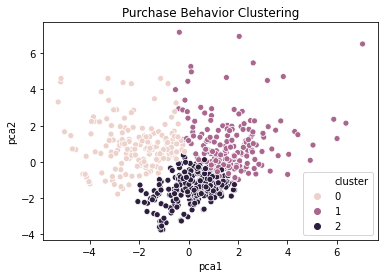

```
The model score is -3424.1247115054407
cluster                    0         1         2
No. of Brands      -0.488579  0.819228 -0.278730
Brand Runs         -0.746790  0.953270 -0.199401
Total Volume       -0.093577  0.788656 -0.532375
No. of  Trans      -0.455814  0.951349 -0.401867
Value              -0.288525  0.869890 -0.457343
Trans / Brand Runs  0.592094 -0.230339 -0.240309
Vol/Tran            0.288390  0.101805 -0.279297
Top Brand %         1.301398 -0.409226 -0.601772
Others 999         -1.188110  0.226689  0.660776
cluster
0    171
1    185
2    244
dtype: int64
```

```python
#Plot clusters, print means, and print distribution of clusters
slim_pb_df = PCA(n_components=2).fit_transform(pb_df)
slim_pb = pd.DataFrame(slim_pb_df,columns=['pca1','pca2'])
sns.scatterplot(x='pca1', y='pca2', hue=pb_df['cluster'], data=slim_pb)
plt.title('Purchase Behavior Clustering')
plt.show()
print(str('The model score is ') + str(pb_score))
print(pb_df.groupby(['cluster']).mean().transpose())
print(pb_df.groupby(['cluster']).size())
```

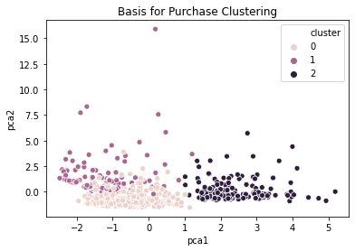

```
The model score is -3606.0157625036604
cluster                       0         1         2
Avg. Price            -0.126126 -1.104224  1.215445
Pur Vol Other Promo % -0.171579  0.333591  0.088763
Pur Vol Promo 6 %     -0.024591 -0.081707  0.123116
Pur Vol Other Promo % -0.171579  0.333591  0.088763
Pr Cat 1              -0.410514 -0.702700  1.491606
Pr Cat 2               0.765203 -1.088860 -0.735843
Pr Cat 3              -0.292866  1.294202 -0.466276
Pr Cat 4              -0.231761  0.989751 -0.339650
Top PropCat %         -0.039685  0.543402 -0.376874
cluster
0    324
1    127
2    149
dtype: int64
```

```python
#Plot clusters, print means, and print distribution of clusters
slim_bfp_df = PCA(n_components=2).fit_transform(bfp_df)
slim_bfp = pd.DataFrame(slim_bfp_df,columns=['pca1','pca2'])
sns.scatterplot(x='pca1', y='pca2', hue=bfp_df['cluster'], data=slim_bfp)
plt.title('Basis for Purchase Clustering')
plt.show()
print(str('The model score is ') + str(bfp_score))
print(bfp_df.groupby(['cluster']).mean().transpose())
print(bfp_df.groupby(['cluster']).size())
```

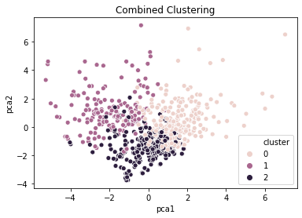

```
The model score is -8214.581108040073
cluster                       0         1         2
No. of Brands          0.849543 -0.508957 -0.497967
Brand Runs             0.887284 -0.728331 -0.381198
Total Volume           0.389539  0.219784 -0.548206
No. of  Trans          0.808080 -0.446888 -0.499943
Value                  0.529633 -0.114090 -0.453892
Trans / Brand Runs    -0.261761  0.634535 -0.183777
Vol/Tran              -0.244305  0.684982 -0.237001
Top Brand %           -0.423358  1.254141 -0.458087
Others 999             0.176070 -1.110031  0.605887
Avg. Price             0.153092 -0.716732  0.351451
Pur Vol Other Promo % -0.055628  0.135250 -0.039339
Pur Vol Promo 6 %      0.188571 -0.421751  0.107430
Pur Vol Other Promo % -0.055628  0.135250 -0.039339
Pr Cat 1               0.091682 -0.759186  0.443384
Pr Cat 2               0.213039  0.079840 -0.271325
Pr Cat 3              -0.220009  0.903586 -0.415825
Pr Cat 4              -0.171913 -0.280595  0.371537
Top PropCat %         -0.766786  0.825262  0.191188
cluster
0    223
1    156
2    221
dtype: int64
```

```python
#Plot clusters, print means, and print distribution of clusters
slim_cmbnd_df = PCA(n_components=2).fit_transform(cmbnd_df)
slim_cmbnd = pd.DataFrame(slim_cmbnd_df,columns=['pca1','pca2'])
sns.scatterplot(x='pca1', y='pca2', hue=cmbnd_df['cluster'], data=slim_pb)
plt.title('Combined Clustering')
plt.show()
print(str('The model score is ') + str(cmbnd_score))
print(cmbnd_df.groupby(['cluster']).mean().transpose())
print(cmbnd_df.groupby(['cluster']).size())
```

#### **Segmentation Selection**

**Chosen Segment is Purchase Behavior because it nets the cleanest clusters**

*Assigns clusters back to the original data set and re-run means for analysis*

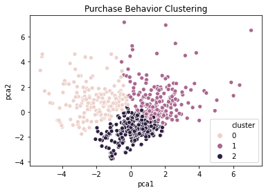

```
cluster                     0.0       1.0       2.0
AGE                   -0.030296  0.147100 -0.090299
Affluence Index       -0.308500  0.298373 -0.010023
Avg. Price            -0.393037  0.070346  0.222112
Br. Cd. 24             0.045097  0.042317 -0.063689
Br. Cd. 272           -0.033578  0.013936  0.012965
Br. Cd. 286            0.080948 -0.022702 -0.039518
Br. Cd. 352            0.226976 -0.025692 -0.139590
Br. Cd. 481            0.077372  0.044103 -0.087662
Br. Cd. 5              0.071281  0.048816 -0.086967
Br. Cd. 55             0.734895 -0.220588 -0.347780
Br. Cd. 57, 144        0.478205 -0.066033 -0.285070
Brand Runs            -0.746790  0.953270 -0.199401
CHILD                  0.207259 -0.262989  0.054146
CS                    -0.118990  0.177444 -0.051147
EDU                   -0.287056  0.219813  0.034512
FEH                   -0.109660  0.281507 -0.136586
HS                    -0.101212  0.481091 -0.293831
MT                    -0.138320  0.269584 -0.107461
Member id             -0.275848 -0.004087  0.196418
No. of  Trans         -0.455814  0.951349 -0.401867
No. of Brands         -0.488579  0.819228 -0.278730
Others 999            -1.188110  0.226689  0.660776
Pr Cat 1              -0.451762  0.052747  0.276611
Pr Cat 2               0.022912  0.154414 -0.133133
Pr Cat 3               0.706220 -0.217952 -0.329683
Pr Cat 4              -0.363099 -0.022208  0.271305
PropCat 10            -0.145137 -0.029460  0.124051
PropCat 11             0.042744  0.033370 -0.055257
PropCat 12            -0.160660  0.019176  0.098054
PropCat 13            -0.010012  0.043896 -0.026265
PropCat 14             0.718442 -0.219753 -0.336882
PropCat 15            -0.255875  0.076691  0.121175
PropCat 5             -0.116861  0.019337  0.067237
PropCat 6             -0.272066  0.125911  0.095204
PropCat 7             -0.118641  0.031972  0.058905
PropCat 8             -0.278439  0.009089  0.188244
PropCat 9             -0.143759  0.187688 -0.041555
Pur Vol No Promo - %   0.230409 -0.060803 -0.115374
Pur Vol Other Promo %  0.046829 -0.046768  0.002641
Pur Vol Promo 6 %     -0.332173  0.118396  0.143026
SEC                    0.222299 -0.012087 -0.146627
SEX                   -0.155727  0.295379 -0.114819
Top Brand %            1.301398 -0.409226 -0.601772
Top PropCat %          0.732508 -0.523969 -0.116084
Total Volume          -0.093577  0.788656 -0.532375
Trans / Brand Runs     0.592094 -0.230339 -0.240309
Value                 -0.288525  0.869890 -0.457343
Vol/Tran               0.288390  0.101805 -0.279297
cluster
0.0    171
1.0    185
2.0    244
dtype: int64
```

```python
#Plot Output
slim_pb_df = PCA(n_components=2).fit_transform(pb_df)
slim_pb = pd.DataFrame(slim_pb_df,columns=['pca1','pca2'])
sns.scatterplot(x='pca1', y='pca2', hue=pb_df['cluster'], data=slim_pb)
plt.title('Purchase Behavior Clustering')
plt.show()
#Add 'cluster' to original normalized dataframe
soap_df_norm = soap_df_norm.add(pb_df[['cluster']],fill_value=0)
#Table output
print(soap_df_norm.groupby(['cluster']).mean().transpose())
print(soap_df_norm.groupby(['cluster']).size())
```

#### **Cluster Analysis**

**Cluster 0 - 'Brand Champions'**

These members tend to gravitate toward one brand *(High Top Brand % vs. low No. of Brands and Others 999)*. This member is not as responsive to promotion *(high Pur Vol No Promo - %)*. Responsive to specific props and price categories *(high PropCat 14, Top PropCat%* and *Pr Cat 3*.

**Cluster 1 - 'Affluent Movers'**

This member spends a lot overall *(High Value, High Total Volume)* and has a propensity for affluence *(high Affluence Index)*. This member skews older and female *(AGE, SEX)*, with others in the household *(HS)*. While this member likes to shop multiple brands, *(high Others 999, low Top Brand %)*, they tend to shop a lot before moving to the next brand *(high Brand Run)*.

**Cluster 2 - 'Thrifty Nomads'**

This member is responsive to promotions *(Pur Vol Promo 6 %, PropCat 15, PropCat 8)*. High likelihood to shop multiple brands *(high Others 999, low Top Brand %)*.